# Regresión Lineal Simple sobre el Rendimiento Académico en Educación Secundaria

Métodos y Simulación Estadística · 20261 — Actividad 3

Juan Alejandro Carrillo Jaimes

2026-04-20

# 1 Introducción

Portugal históricamente presenta un elevado índice de fracaso escolar, particularmente en asignaturas claves como Matemáticas y Lengua Portuguesa (Cortez & Silva, 2008). Este trabajo tiene como fin estudiar el rendimiento académico secundario a través de un **modelo de regresión lineal simple**, tomando la calificación final (G3, [0-20]) como variable respuesta y el número de materias reprobadas (failures) como variable predictora. El análisis se realiza de forma independiente para cada una de las materias **(MAT y POR)**, y comprende exploración descriptiva, ajuste del modelo mediante mínimos cuadrados ordinarios (MCO), evaluación estadística, diagnóstico de supuestos, análisis de observaciones influyentes, e intervalos de confianza y predicción.

El análisis se limita a modelos de regresión lineal simple con una única variable predictora cuantitativa, tal y como se propone en la Unidad 3 del curso. Todo lo que rodea a G1 y G2 (notas de periodos anteriores) queda fuera de las candidatas al ser también variables de respuesta intermedia; se busca, no obstante, una variable explicativa externa al proceso de evaluación.

El análisis se encarama exclusivamente con **modelos de la regresión lineal simple** con una única variable de respuesta de tipo cuantitativo, tal como se establece en la Unidad 3 del curso. Se desecha por tanto a `G1`, por un lado, y a `G2`, por el otro, que son variables de periodo anterior ya que son variables de respuesta intermedia; se busca una variable explicativa **externa** al proceso evaluativo.

# 2 Exploración de Datos

## 2.1 Descripción del conjunto de datos

Los datos provienen de dos escuelas secundarias públicas de la región de Alentejo, Portugal, durante el año escolar 2005–2006. Se dispone de dos conjuntos de datos: uno para Matemáticas (MAT, $n = 395$) y otro para Portugués (POR, $n = 649$). Cada registro incluye calificaciones, características demográficas, factores sociales y aspectos escolares (Cortez & Silva, 2008).

```r
# Carga de datos — ajusta la ruta si es necesario
mat <- read.csv("student-mat.csv", sep = ";", header = TRUE)
por <- read.csv("student-por.csv", sep = ";", header = TRUE)

cat("MAT:", nrow(mat), "observaciones |",
    "POR:", nrow(por), "observaciones\n")
```

```
## MAT: 395 observaciones | POR: 649 observaciones
```

```r
cat("Variables:", ncol(mat), "\n")
```

```
## Variables: 33
```

## 2.2 Estadísticas descriptivas de G3

```r
library(knitr)
library(moments)

desc_tabla <- function(x, nombre) {
  data.frame(
    Estadístico = c("N", "Media", "Mediana", "Desv. estándar",
                    "Mínimo", "Q1", "Q3", "Máximo",
                    "Asimetría", "Curtosis"),
    Valor = c(
      length(x),
      round(mean(x),     3),
      round(median(x),   3),
      round(sd(x),       3),
      min(x),
      as.numeric(quantile(x, 0.25)),
      as.numeric(quantile(x, 0.75)),
      max(x),
      round(skewness(x), 3),
      round(kurtosis(x), 3)
    ),
    Materia = nombre
  )
}

tab_desc <- rbind(desc_tabla(mat$G3, "MAT"), desc_tabla(por$G3, "POR"))

# Formato ancho
library(tidyr)
tab_wide <- pivot_wider(tab_desc, names_from = Materia, values_from = Valor)

kable(tab_wide,
      caption = "Estadísticas descriptivas de la nota final (G3) por materia.",
      align   = c("l", "r", "r"))
```

Table 2.1: Estadísticas descriptivas de la nota final (G3) por materia.

| Estadístico | MAT | POR |
| --- | --- | --- |
| N | 395.000 | 649.000 |
| Media | 10.415 | 11.906 |
| Mediana | 11.000 | 12.000 |
| Desv. estándar | 4.581 | 3.231 |
| Mínimo | 0.000 | 0.000 |
| Q1 | 8.000 | 10.000 |
| Q3 | 14.000 | 14.000 |
| Máximo | 20.000 | 19.000 |
| Asimetría | -0.730 | -0.911 |
| Curtosis | 3.383 | 5.682 |

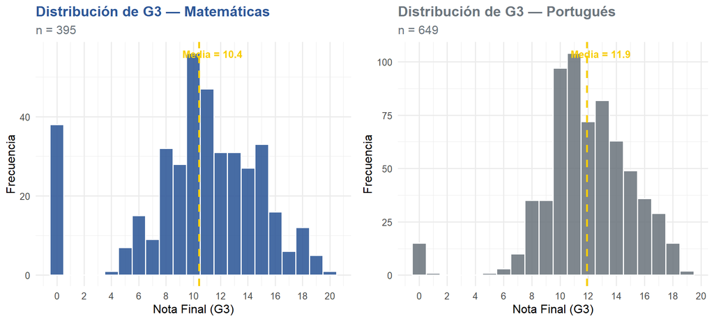

Figure 2.1: Distribución de la nota final (G3) para Matemáticas y Portugués. La línea amarilla indica la media.

```r
library(ggplot2)
library(gridExtra)

p1 <- ggplot(mat, aes(x = G3)) +
  geom_histogram(binwidth = 1, fill = col_azul, color = "white", alpha = 0.87) +
  geom_vline(xintercept = mean(mat$G3), color = col_amar,
             linetype = "dashed", linewidth = 1) +
  annotate("text", x = mean(mat$G3) + 1, y = Inf,
           label = paste0("Media = ", round(mean(mat$G3), 1)),
           vjust = 2, color = col_amar, size = 3.5, fontface = "bold") +
  labs(title    = "Distribución de G3 — Matemáticas",
       subtitle = paste0("n = ", nrow(mat)),
       x = "Nota Final (G3)", y = "Frecuencia") +
  scale_x_continuous(breaks = seq(0, 20, 2)) +
  theme_minimal(base_size = 12) +
  theme(plot.title    = element_text(color = col_azul, face = "bold"),
        plot.subtitle = element_text(color = col_gris))

p2 <- ggplot(por, aes(x = G3)) +
  geom_histogram(binwidth = 1, fill = col_gris, color = "white", alpha = 0.87) +
  geom_vline(xintercept = mean(por$G3), color = col_amar,
             linetype = "dashed", linewidth = 1) +
  annotate("text", x = mean(por$G3) + 1, y = Inf,
           label = paste0("Media = ", round(mean(por$G3), 1)),
           vjust = 2, color = col_amar, size = 3.5, fontface = "bold") +
  labs(title    = "Distribución de G3 — Portugués",
       subtitle = paste0("n = ", nrow(por)),
       x = "Nota Final (G3)", y = "Frecuencia") +
  scale_x_continuous(breaks = seq(0, 20, 2)) +
  theme_minimal(base_size = 12) +
  theme(plot.title    = element_text(color = col_gris, face = "bold"),
        plot.subtitle = element_text(color = col_gris))

grid.arrange(p1, p2, ncol = 2)
```

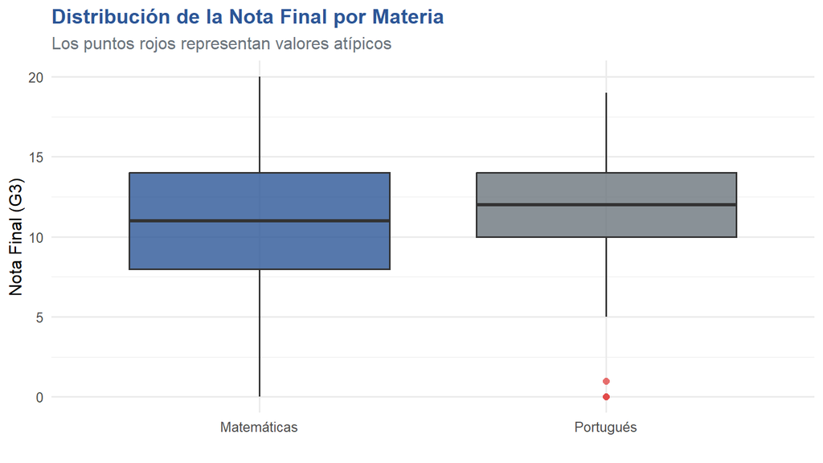

Figure 2.2: Boxplot comparativo de G3 por materia. Los puntos rojos representan valores atípicos.

```r
df_box <- rbind(
  data.frame(G3 = mat$G3, Materia = "Matemáticas"),
  data.frame(G3 = por$G3, Materia = "Portugués")
)

ggplot(df_box, aes(x = Materia, y = G3, fill = Materia)) +
  geom_boxplot(alpha = 0.8, outlier.colour = col_rojo,
               outlier.shape = 16, outlier.size = 2) +
  scale_fill_manual(values = c("Matemáticas" = col_azul,
                                "Portugués"   = col_gris)) +
  labs(title    = "Distribución de la Nota Final por Materia",
       subtitle = "Los puntos rojos representan valores atípicos",
       x = "", y = "Nota Final (G3)") +
  theme_minimal(base_size = 12) +
  theme(legend.position = "none",
        plot.title    = element_text(face = "bold", color = col_azul),
        plot.subtitle = element_text(color = col_gris))
```

## 2.3 Selección de la variable predictora

Se calcularon los coeficientes de correlación de Pearson entre cada variable cuantitativa candidata y G3. Las variables `G1` y `G2` se excluyen por ser notas de período; se busca un predictor **externo** al proceso evaluativo.

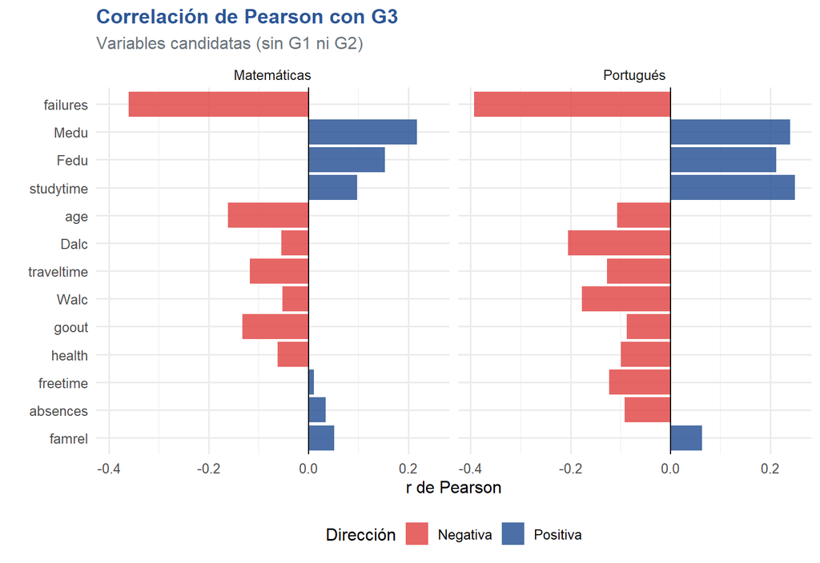

Figure 2.3: Correlación de Pearson entre variables candidatas y G3, para Matemáticas y Portugués.

```r
candidatas <- c("age", "Medu", "Fedu", "traveltime", "studytime",
                "failures", "famrel", "freetime", "goout",
                "Dalc", "Walc", "health", "absences")

corr_mat <- sapply(candidatas, function(v) cor(mat[[v]], mat$G3))
corr_por <- sapply(candidatas, function(v) cor(por[[v]], por$G3))

corr_mat_ord <- sort(abs(corr_mat), decreasing = TRUE)
corr_por_ord <- sort(abs(corr_por), decreasing = TRUE)

df_corr <- rbind(
  data.frame(variable = names(corr_mat), r = as.numeric(corr_mat),
             materia = "Matemáticas"),
  data.frame(variable = names(corr_por), r = as.numeric(corr_por),
             materia  = "Portugués")
)

ggplot(df_corr, aes(x = reorder(variable, abs(r)), y = r,
                    fill = ifelse(r >= 0, "Positiva", "Negativa"))) +
  geom_col(alpha = 0.85) +
  geom_hline(yintercept = 0, color = "black", linewidth = 0.4) +
  coord_flip() +
  scale_fill_manual(values = c("Positiva" = col_azul, "Negativa" = col_rojo),
                    name = "Dirección") +
  facet_wrap(~ materia) +
  labs(title    = "Correlación de Pearson con G3",
       subtitle = "Variables candidatas (sin G1 ni G2)",
       x = "", y = "r de Pearson") +
  theme_minimal(base_size = 12) +
  theme(plot.title      = element_text(face = "bold", color = col_azul),
        plot.subtitle   = element_text(color = col_gris),
        legend.position = "bottom")
```

```r
top3_mat <- data.frame(
  Posición  = 1:3,
  Variable  = names(head(corr_mat_ord, 3)),
  `|r|`     = round(head(corr_mat_ord, 3), 4),
  r         = round(corr_mat[names(head(corr_mat_ord, 3))], 4),
  Materia   = "MAT"
)
top3_por <- data.frame(
  Posición  = 1:3,
  Variable  = names(head(corr_por_ord, 3)),
  `|r|`     = round(head(corr_por_ord, 3), 4),
  r         = round(corr_por[names(head(corr_por_ord, 3))], 4),
  Materia   = "POR"
)

kable(rbind(top3_mat, top3_por),
      caption = "Top 3 variables con mayor correlación absoluta con G3.",
      row.names = FALSE)
```

Table 2.2: Top 3 variables con mayor correlación absoluta con G3.

| Posición | Variable | X.r. | r | Materia |
| --- | --- | --- | --- | --- |
| 1 | failures | 0.3604 | -0.3604 | MAT |
| 2 | Medu | 0.2171 | 0.2171 | MAT |
| 3 | age | 0.1616 | -0.1616 | MAT |
| 1 | failures | 0.3933 | -0.3933 | POR |
| 2 | studytime | 0.2498 | 0.2498 | POR |
| 3 | Medu | 0.2402 | 0.2402 | POR |

**Variable predictora seleccionada: `failures`** (número de materias reprobadas previamente).

- MAT: $r = -0.3604$ — la correlación negativa más fuerte entre las candidatas.
- POR: $r = -0.3933$ — correlación negativa aún más pronunciada.

La relación tiene sentido práctico: los estudiantes con mayor historial de reprobación tienden a obtener calificaciones finales más bajas.

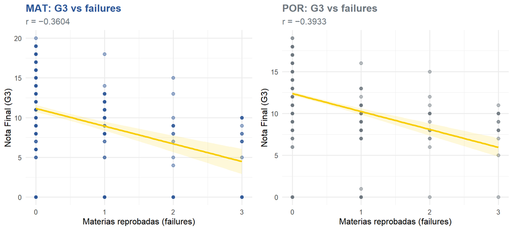

Figure 2.4: Diagrama de dispersión de G3 vs failures con recta de regresión lineal.

```r
p_mat <- ggplot(mat, aes(x = failures, y = G3)) +
  geom_point(color = col_azul, alpha = 0.45, size = 2) +
  geom_smooth(method = "lm", color = col_amar, se = TRUE,
              fill = col_amar, alpha = 0.15) +
  labs(title    = "MAT: G3 vs failures",
       subtitle = "r = −0.3604",
       x = "Materias reprobadas (failures)", y = "Nota Final (G3)") +
  theme_minimal(base_size = 12) +
  theme(plot.title    = element_text(color = col_azul, face = "bold"),
        plot.subtitle = element_text(color = col_gris))

p_por <- ggplot(por, aes(x = failures, y = G3)) +
  geom_point(color = col_gris, alpha = 0.45, size = 2) +
  geom_smooth(method = "lm", color = col_amar, se = TRUE,
              fill = col_amar, alpha = 0.15) +
  labs(title    = "POR: G3 vs failures",
       subtitle = "r = −0.3933",
       x = "Materias reprobadas (failures)", y = "Nota Final (G3)") +
  theme_minimal(base_size = 12) +
  theme(plot.title    = element_text(color = col_gris, face = "bold"),
        plot.subtitle = element_text(color = col_gris))

grid.arrange(p_mat, p_por, ncol = 2)
```

# 3 Modelo de Regresión Lineal Simple

El modelo propuesto es:

$$G3_i = \beta_0 + \beta_1 \cdot \text{failures}_i + \varepsilon_i, \quad \varepsilon_i \sim \mathcal{N}(0, \sigma^2)$$

donde $\beta_0$ es el intercepto, $\beta_1$ la pendiente, y $\varepsilon_i$ el término de error con varianza constante.

## 3.1 Ajuste del modelo — Matemáticas (MAT)

```r
# Variables
x_mat <- mat$failures
y_mat <- mat$G3
n_mat <- length(y_mat)

# Sumas de cuadrados
x_bar_mat <- mean(x_mat);  y_bar_mat <- mean(y_mat)
Sxx_mat   <- sum((x_mat - x_bar_mat)^2)
Sxy_mat   <- sum((x_mat - x_bar_mat) * (y_mat - y_bar_mat))
Syy_mat   <- sum((y_mat - y_bar_mat)^2)

# Estimadores MCO
b1_mat <- Sxy_mat / Sxx_mat
b0_mat <- y_bar_mat - b1_mat * x_bar_mat

# Ajuste con lm()
modelo_mat <- lm(G3 ~ failures, data = mat)
summary(modelo_mat)
```

```
##
## Call:
## lm(formula = G3 ~ failures, data = mat)
##
## Residuals:
##      Min       1Q   Median       3Q      Max
## -11.1572  -2.1572  -0.1572   2.8428   9.0632
##
## Coefficients:
##             Estimate Std. Error t value Pr(>|t|)
## (Intercept)  11.1572     0.2361   47.26  < 2e-16 ***
## failures     -2.2204     0.2899   -7.66 1.47e-13 ***
## ---
## Signif. codes:  0 '***' 0.001 '**' 0.01 '*' 0.05 '.' 0.1 ' ' 1
##
## Residual standard error: 4.279 on 393 degrees of freedom
## Multiple R-squared:  0.1299, Adjusted R-squared:  0.1277
## F-statistic: 58.67 on 1 and 393 DF,  p-value: 1.466e-13
```

```r
s_mat     <- summary(modelo_mat)
CME_mat   <- s_mat$sigma^2
sigma_mat <- s_mat$sigma

# Sumas de cuadrados
SCReg_mat <- b1_mat^2 * Sxx_mat
SCE_mat   <- Syy_mat - SCReg_mat
R2_mat    <- SCReg_mat / Syy_mat
F_mat     <- (SCReg_mat / 1) / CME_mat
p_F_mat   <- pf(F_mat, 1, n_mat - 2, lower.tail = FALSE)

SE_b1_mat <- sqrt(CME_mat / Sxx_mat)
SE_b0_mat <- sqrt(CME_mat * (1/n_mat + x_bar_mat^2 / Sxx_mat))
t_b1_mat  <- b1_mat / SE_b1_mat
t_b0_mat  <- b0_mat / SE_b0_mat
p_b1_mat  <- 2 * pt(abs(t_b1_mat), df = n_mat - 2, lower.tail = FALSE)
p_b0_mat  <- 2 * pt(abs(t_b0_mat), df = n_mat - 2, lower.tail = FALSE)

tab_mat <- data.frame(
  Parámetro    = c("β̂₀ (Intercepto)", "β̂₁ (failures)"),
  Estimación   = round(c(b0_mat, b1_mat), 4),
  `Error Std.` = round(c(SE_b0_mat, SE_b1_mat), 4),
  `t`          = round(c(t_b0_mat, t_b1_mat), 4),
  `p-valor`    = format.pval(c(p_b0_mat, p_b1_mat), digits = 4, eps = 0.0001)
)

kable(tab_mat,
      caption = "Estimaciones MCO del modelo G3 ~ failures — Matemáticas.",
      row.names = FALSE)
```

Table 3.1: Estimaciones MCO del modelo G3 ~ failures — Matemáticas.

| Parámetro | Estimación | Error.Std. | t | p.valor |
| --- | --- | --- | --- | --- |
| β̂₀ (Intercepto) | 11.1572 | 0.2361 | 47.2587 | < 1e-04 |
| β̂₁ (failures) | -2.2204 | 0.2899 | -7.6597 | < 1e-04 |

```r
anova_tab_mat <- data.frame(
  Fuente = c("Regresión", "Error", "Total"),
  GL     = c(1, n_mat - 2, n_mat - 1),
  SC     = round(c(SCReg_mat, SCE_mat, Syy_mat), 3),
  CM     = round(c(SCReg_mat, CME_mat, NA), 3),
  F      = c(round(F_mat, 4), NA, NA),
  `p-valor` = c(format.pval(p_F_mat, digits = 4, eps = 0.0001), NA, NA)
)

kable(anova_tab_mat,
      caption = "Tabla ANOVA del modelo de regresión — Matemáticas.",
      row.names = FALSE, na.print = "")
```

Table 3.2: Tabla ANOVA del modelo de regresión — Matemáticas.

| Fuente | GL | SC | CM | F | p.valor |
| --- | --- | --- | --- | --- | --- |
| Regresión | 1 | 1074.252 | 1074.252 | 58.6717 | < 1e-04 |
| Error | 393 | 7195.657 | 18.310 | NA | NA |
| Total | 394 | 8269.909 | NA | NA | NA |

**MAT** — Modelo estimado: $\widehat{G3} = 11.1572 + (-2.2204) \cdot \text{failures}$

- $R^2 = 0.1299$: el modelo explica el 13% de la variabilidad en G3.
- Prueba F: $F = 58.672$, $p < 0.001$ → el modelo es estadísticamente significativo.
- $\hat{\beta}_1 = -2.2204$: por cada materia reprobada adicional, la nota final disminuye en promedio 2.2204 puntos.

## 3.2 Ajuste del modelo — Portugués (POR)

```r
x_por <- por$failures
y_por <- por$G3
n_por <- length(y_por)

x_bar_por <- mean(x_por);  y_bar_por <- mean(y_por)
Sxx_por   <- sum((x_por - x_bar_por)^2)
Sxy_por   <- sum((x_por - x_bar_por) * (y_por - y_bar_por))
Syy_por   <- sum((y_por - y_bar_por)^2)

b1_por <- Sxy_por / Sxx_por
b0_por <- y_bar_por - b1_por * x_bar_por

modelo_por <- lm(G3 ~ failures, data = por)
summary(modelo_por)
```

```
##
## Call:
## lm(formula = G3 ~ failures, data = por)
##
## Residuals:
##      Min       1Q   Median       3Q      Max
## -12.3813  -1.3813  -0.2393   1.6187   6.9026
##
## Coefficients:
##             Estimate Std. Error t value Pr(>|t|)
## (Intercept)  12.3813     0.1246   99.38   <2e-16 ***
## failures     -2.1419     0.1968  -10.88   <2e-16 ***
## ---
## Signif. codes:  0 '***' 0.001 '**' 0.01 '*' 0.05 '.' 0.1 ' ' 1
##
## Residual standard error: 2.973 on 647 degrees of freedom
## Multiple R-squared:  0.1547, Adjusted R-squared:  0.1534
## F-statistic: 118.4 on 1 and 647 DF,  p-value: < 2.2e-16
```

```r
s_por     <- summary(modelo_por)
CME_por   <- s_por$sigma^2
sigma_por <- s_por$sigma

SCReg_por <- b1_por^2 * Sxx_por
SCE_por   <- Syy_por - SCReg_por
R2_por    <- SCReg_por / Syy_por
F_por     <- (SCReg_por / 1) / CME_por
p_F_por   <- pf(F_por, 1, n_por - 2, lower.tail = FALSE)

SE_b1_por <- sqrt(CME_por / Sxx_por)
SE_b0_por <- sqrt(CME_por * (1/n_por + x_bar_por^2 / Sxx_por))
t_b1_por  <- b1_por / SE_b1_por
t_b0_por  <- b0_por / SE_b0_por
p_b1_por  <- 2 * pt(abs(t_b1_por), df = n_por - 2, lower.tail = FALSE)
p_b0_por  <- 2 * pt(abs(t_b0_por), df = n_por - 2, lower.tail = FALSE)

tab_por <- data.frame(
  Parámetro    = c("β̂₀ (Intercepto)", "β̂₁ (failures)"),
  Estimación   = round(c(b0_por, b1_por), 4),
  `Error Std.` = round(c(SE_b0_por, SE_b1_por), 4),
  `t`          = round(c(t_b0_por, t_b1_por), 4),
  `p-valor`    = format.pval(c(p_b0_por, p_b1_por), digits = 4, eps = 0.0001)
)

kable(tab_por,
      caption = "Estimaciones MCO del modelo G3 ~ failures — Portugués.",
      row.names = FALSE)
```

Table 3.3: Estimaciones MCO del modelo G3 ~ failures — Portugués.

| Parámetro | Estimación | Error.Std. | t | p.valor |
| --- | --- | --- | --- | --- |
| β̂₀ (Intercepto) | 12.3813 | 0.1246 | 99.3763 | < 1e-04 |
| β̂₁ (failures) | -2.1419 | 0.1968 | -10.8815 | < 1e-04 |

```r
anova_tab_por <- data.frame(
  Fuente = c("Regresión", "Error", "Total"),
  GL     = c(1, n_por - 2, n_por - 1),
  SC     = round(c(SCReg_por, SCE_por, Syy_por), 3),
  CM     = round(c(SCReg_por, CME_por, NA), 3),
  F      = c(round(F_por, 4), NA, NA),
  `p-valor` = c(format.pval(p_F_por, digits = 4, eps = 0.0001), NA, NA)
)

kable(anova_tab_por,
      caption = "Tabla ANOVA del modelo de regresión — Portugués.",
      row.names = FALSE, na.print = "")
```

Table 3.4: Tabla ANOVA del modelo de regresión — Portugués.

| Fuente | GL | SC | CM | F | p.valor |
| --- | --- | --- | --- | --- | --- |
| Regresión | 1 | 1046.258 | 1046.258 | 118.4061 | < 1e-04 |
| Error | 647 | 5717.009 | 8.836 | NA | NA |
| Total | 648 | 6763.267 | NA | NA | NA |

**POR** — Modelo estimado: $\widehat{G3} = 12.3813 + (-2.1419) \cdot \text{failures}$

- $R^2 = 0.1547$: el modelo explica el 15.5% de la variabilidad en G3.
- Prueba F: $F = 118.406$, $p < 0.001$ → el modelo es estadísticamente significativo.
- $\hat{\beta}_1 = -2.1419$: por cada materia reprobada adicional, la nota final disminuye en promedio 2.1419 puntos.

# 4 Análisis de Diagnóstico

Se verifican los cuatro supuestos del modelo de regresión lineal simple: **linealidad**, **independencia**, **homocedasticidad** y **normalidad** de los residuos.

## 4.1 Diagnóstico — Matemáticas

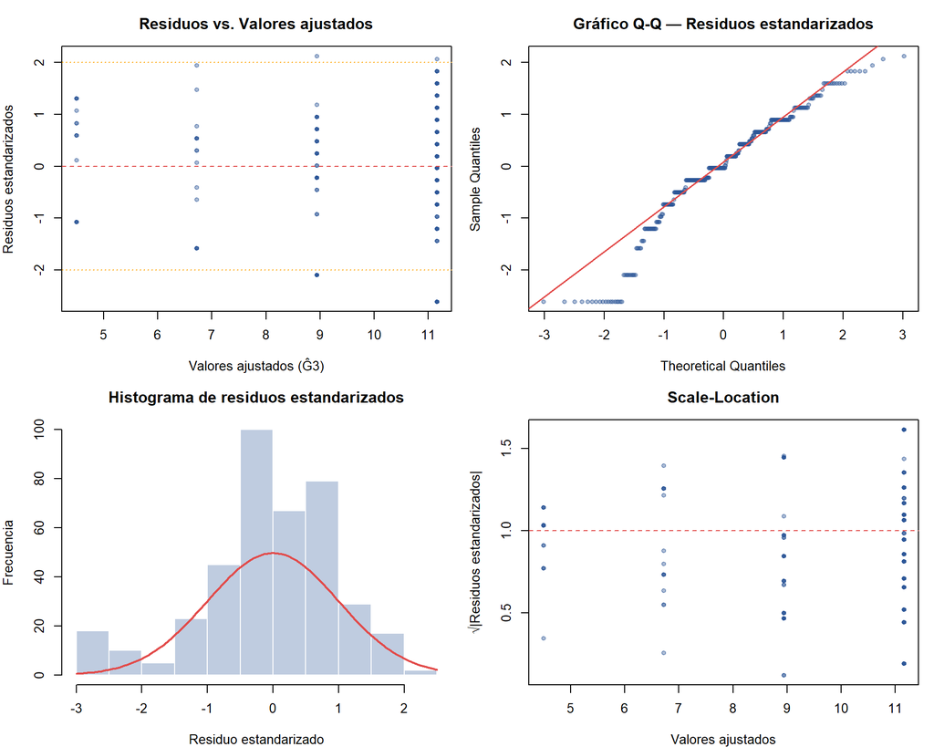

Figure 4.1: Gráficos de diagnóstico del modelo G3 ~ failures — Matemáticas.

```r
library(nortest)

y_hat_mat  <- fitted(modelo_mat)
res_mat    <- residuals(modelo_mat)
res_std_mat <- rstandard(modelo_mat)

par(mfrow = c(2, 2), mar = c(4, 4, 3, 1))

# 1. Residuos vs ajustados
plot(y_hat_mat, res_std_mat,
     xlab = "Valores ajustados (Ĝ3)", ylab = "Residuos estandarizados",
     main = "Residuos vs. Valores ajustados",
     pch = 19, col = adjustcolor(col_azul, 0.4), cex = 0.75)
abline(h = 0,      lty = 2, col = col_rojo)
abline(h = c(-2, 2), lty = 3, col = "orange")

# 2. Q-Q
qqnorm(res_std_mat, main = "Gráfico Q-Q — Residuos estandarizados",
       pch = 19, col = adjustcolor(col_azul, 0.4), cex = 0.75)
qqline(res_std_mat, col = col_rojo, lwd = 1.5)

# 3. Histograma de residuos
hist(res_std_mat, main = "Histograma de residuos estandarizados",
     xlab = "Residuo estandarizado", ylab = "Frecuencia",
     col = adjustcolor(col_azul, 0.3), border = "white", breaks = 15)
curve(dnorm(x) * n_mat * diff(range(res_std_mat)) / 15,
      add = TRUE, col = col_rojo, lwd = 2)

# 4. Scale-Location
plot(y_hat_mat, sqrt(abs(res_std_mat)),
     xlab = "Valores ajustados", ylab = "√|Residuos estandarizados|",
     main = "Scale-Location",
     pch = 19, col = adjustcolor(col_azul, 0.4), cex = 0.75)
abline(h = 1, lty = 2, col = col_rojo)
```

```r
par(mfrow = c(1, 1))
```

```r
# Prueba de normalidad Shapiro-Wilk
sw_mat <- shapiro.test(res_mat)

# Prueba de Breusch-Pagan (homocedasticidad) - manual via lmtest si disponible
# Si no tienes lmtest, usamos la correlación de Spearman de |residuos| vs ajustados
sp_mat <- cor.test(abs(res_mat), y_hat_mat, method = "spearman")

tab_pruebas_mat <- data.frame(
  Prueba      = c("Shapiro-Wilk (normalidad)",
                  "Spearman |e| vs ŷ (homocedasticidad)"),
  Estadístico = c(round(sw_mat$statistic, 4),
                  round(sp_mat$estimate, 4)),
  `p-valor`   = c(format.pval(sw_mat$p.value,  digits = 4, eps = 0.0001),
                  format.pval(sp_mat$p.value,   digits = 4, eps = 0.0001)),
  Conclusión  = c(
    ifelse(sw_mat$p.value < ALPHA,
           "Rechaza normalidad", "No rechaza normalidad"),
    ifelse(sp_mat$p.value < ALPHA,
           "Posible heterocedasticidad", "No rechaza homocedasticidad")
  )
)

kable(tab_pruebas_mat,
      caption = "Pruebas de supuestos del modelo — Matemáticas.",
      row.names = FALSE)
```

Table 4.1: Pruebas de supuestos del modelo — Matemáticas.

| Prueba | Estadístico | p.valor | Conclusión |
| --- | --- | --- | --- |
| Shapiro-Wilk (normalidad) | 0.9493 | < 1e-04 | Rechaza normalidad |
| Spearman \|e\| vs ŷ (homocedasticidad) | 0.2387 | < 1e-04 | Posible heterocedasticidad |

## 4.2 Diagnóstico — Portugués

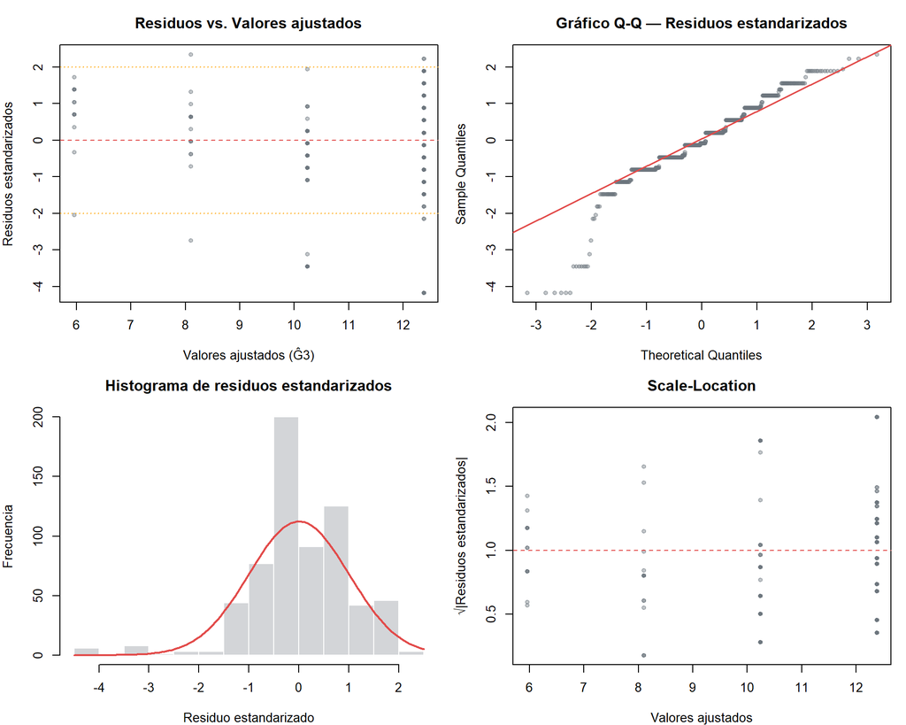

Figure 4.2: Gráficos de diagnóstico del modelo G3 ~ failures — Portugués.

```r
y_hat_por   <- fitted(modelo_por)
res_por     <- residuals(modelo_por)
res_std_por <- rstandard(modelo_por)

par(mfrow = c(2, 2), mar = c(4, 4, 3, 1))

plot(y_hat_por, res_std_por,
     xlab = "Valores ajustados (Ĝ3)", ylab = "Residuos estandarizados",
     main = "Residuos vs. Valores ajustados",
     pch = 19, col = adjustcolor(col_gris, 0.4), cex = 0.75)
abline(h = 0, lty = 2, col = col_rojo)
abline(h = c(-2, 2), lty = 3, col = "orange")

qqnorm(res_std_por, main = "Gráfico Q-Q — Residuos estandarizados",
       pch = 19, col = adjustcolor(col_gris, 0.4), cex = 0.75)
qqline(res_std_por, col = col_rojo, lwd = 1.5)

hist(res_std_por, main = "Histograma de residuos estandarizados",
     xlab = "Residuo estandarizado", ylab = "Frecuencia",
     col = adjustcolor(col_gris, 0.3), border = "white", breaks = 15)
curve(dnorm(x) * n_por * diff(range(res_std_por)) / 15,
      add = TRUE, col = col_rojo, lwd = 2)

plot(y_hat_por, sqrt(abs(res_std_por)),
     xlab = "Valores ajustados", ylab = "√|Residuos estandarizados|",
     main = "Scale-Location",
     pch = 19, col = adjustcolor(col_gris, 0.4), cex = 0.75)
abline(h = 1, lty = 2, col = col_rojo)
```

```r
par(mfrow = c(1, 1))
```

```r
sw_por <- shapiro.test(res_por)
sp_por <- cor.test(abs(res_por), y_hat_por, method = "spearman")

tab_pruebas_por <- data.frame(
  Prueba      = c("Shapiro-Wilk (normalidad)",
                  "Spearman |e| vs ŷ (homocedasticidad)"),
  Estadístico = c(round(sw_por$statistic, 4),
                  round(sp_por$estimate, 4)),
  `p-valor`   = c(format.pval(sw_por$p.value, digits = 4, eps = 0.0001),
                  format.pval(sp_por$p.value,  digits = 4, eps = 0.0001)),
  Conclusión  = c(
    ifelse(sw_por$p.value < ALPHA,
           "Rechaza normalidad", "No rechaza normalidad"),
    ifelse(sp_por$p.value < ALPHA,
           "Posible heterocedasticidad", "No rechaza homocedasticidad")
  )
)

kable(tab_pruebas_por,
      caption = "Pruebas de supuestos del modelo — Portugués.",
      row.names = FALSE)
```

Table 4.2: Pruebas de supuestos del modelo — Portugués.

| Prueba | Estadístico | p.valor | Conclusión |
| --- | --- | --- | --- |
| Shapiro-Wilk (normalidad) | 0.9339 | < 1e-04 | Rechaza normalidad |
| Spearman \|e\| vs ŷ (homocedasticidad) | 0.2419 | < 1e-04 | Posible heterocedasticidad |

# 5 Análisis de Datos Atípicos e Influyentes

Se emplean tres métricas complementarias: **residuos estandarizados** (valores $|e_i^*| > 2$ son sospechosos), **apalancamiento** (*leverage* $h_{ii}$, umbral $2p/n$) y **distancia de Cook** ($D_i$, umbral $4/n$).

## 5.1 Observaciones influyentes — Matemáticas

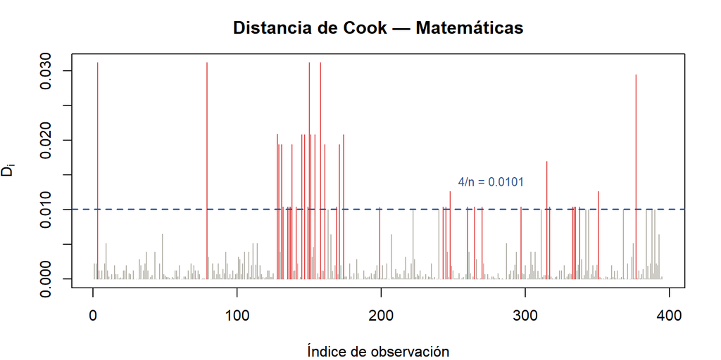

Figure 5.1: Distancia de Cook por observación — Matemáticas. Las barras rojas superan el umbral 4/n.

```r
cook_mat    <- cooks.distance(modelo_mat)
hat_mat     <- hatvalues(modelo_mat)
umbral_mat  <- 4 / n_mat
umbral_hat  <- 2 * 2 / n_mat   # 2p/n con p=2

# Observaciones que superan al menos un umbral
influyentes_mat <- which(cook_mat > umbral_mat | abs(res_std_mat) > 2)

par(mar = c(4, 4, 3, 2))
plot(seq_len(n_mat), cook_mat,
     type = "h",
     xlab = "Índice de observación", ylab = expression(D[i]),
     main = "Distancia de Cook — Matemáticas",
     col  = ifelse(cook_mat > umbral_mat, col_rojo, "#B4B2A9"))
abline(h = umbral_mat, lty = 2, col = col_azul, lwd = 1.5)
text(x = n_mat * 0.7, y = umbral_mat * 1.4,
     labels = sprintf("4/n = %.4f", umbral_mat),
     col = col_azul, cex = 0.8)
```

```r
if (length(influyentes_mat) > 0) {
  tab_inf_mat <- data.frame(
    Obs        = influyentes_mat,
    failures   = mat$failures[influyentes_mat],
    G3         = mat$G3[influyentes_mat],
    Res.Std    = round(res_std_mat[influyentes_mat], 3),
    Leverage   = round(hat_mat[influyentes_mat], 4),
    Cook.D     = round(cook_mat[influyentes_mat], 4)
  )
  kable(tab_inf_mat,
        caption = paste0("Observaciones con residuo estandarizado > 2 o",
                         " distancia de Cook > 4/n — Matemáticas."),
        row.names = FALSE)
} else {
  cat("No se identificaron observaciones influyentes bajo los umbrales definidos.\n")
}
```

Table 5.1: Observaciones con residuo estandarizado > 2 o distancia de Cook > 4/n — Matemáticas.

| Obs | failures | G3 | Res.Std | Leverage | Cook.D |
| --- | --- | --- | --- | --- | --- |
| 3 | 3 | 10 | 1.310 | 0.0351 | 0.0312 |
| 48 | 0 | 20 | 2.070 | 0.0030 | 0.0065 |
| 79 | 3 | 10 | 1.310 | 0.0351 | 0.0312 |
| 128 | 3 | 9 | 1.072 | 0.0351 | 0.0209 |
| 129 | 2 | 0 | -1.582 | 0.0153 | 0.0194 |
| 131 | 2 | 0 | -1.582 | 0.0153 | 0.0194 |
| 132 | 0 | 0 | -2.611 | 0.0030 | 0.0104 |
| 135 | 0 | 0 | -2.611 | 0.0030 | 0.0104 |
| 136 | 0 | 0 | -2.611 | 0.0030 | 0.0104 |
| 137 | 0 | 0 | -2.611 | 0.0030 | 0.0104 |
| 138 | 2 | 0 | -1.582 | 0.0153 | 0.0194 |
| 141 | 0 | 0 | -2.611 | 0.0030 | 0.0104 |
| 145 | 3 | 0 | -1.070 | 0.0351 | 0.0208 |
| 147 | 3 | 0 | -1.070 | 0.0351 | 0.0208 |
| 149 | 0 | 0 | -2.611 | 0.0030 | 0.0104 |
| 150 | 3 | 10 | 1.310 | 0.0351 | 0.0312 |
| 151 | 3 | 0 | -1.070 | 0.0351 | 0.0208 |
| 154 | 3 | 0 | -1.070 | 0.0351 | 0.0208 |
| 158 | 3 | 10 | 1.310 | 0.0351 | 0.0312 |
| 161 | 2 | 0 | -1.582 | 0.0153 | 0.0194 |
| 163 | 1 | 0 | -2.093 | 0.0046 | 0.0101 |
| 169 | 0 | 0 | -2.611 | 0.0030 | 0.0104 |
| 171 | 2 | 0 | -1.582 | 0.0153 | 0.0194 |
| 174 | 3 | 0 | -1.070 | 0.0351 | 0.0208 |
| 199 | 1 | 18 | 2.123 | 0.0046 | 0.0103 |
| 222 | 1 | 0 | -2.093 | 0.0046 | 0.0101 |
| 240 | 1 | 0 | -2.093 | 0.0046 | 0.0101 |
| 243 | 0 | 0 | -2.611 | 0.0030 | 0.0104 |
| 245 | 0 | 0 | -2.611 | 0.0030 | 0.0104 |
| 248 | 3 | 8 | 0.834 | 0.0351 | 0.0127 |
| 260 | 0 | 0 | -2.611 | 0.0030 | 0.0104 |
| 265 | 0 | 0 | -2.611 | 0.0030 | 0.0104 |
| 270 | 0 | 0 | -2.611 | 0.0030 | 0.0104 |
| 297 | 0 | 0 | -2.611 | 0.0030 | 0.0104 |
| 311 | 1 | 0 | -2.093 | 0.0046 | 0.0101 |
| 315 | 2 | 13 | 1.480 | 0.0153 | 0.0170 |
| 317 | 0 | 0 | -2.611 | 0.0030 | 0.0104 |
| 333 | 0 | 0 | -2.611 | 0.0030 | 0.0104 |
| 334 | 0 | 0 | -2.611 | 0.0030 | 0.0104 |
| 335 | 0 | 0 | -2.611 | 0.0030 | 0.0104 |
| 338 | 0 | 0 | -2.611 | 0.0030 | 0.0104 |
| 342 | 1 | 0 | -2.093 | 0.0046 | 0.0101 |
| 344 | 1 | 0 | -2.093 | 0.0046 | 0.0101 |
| 351 | 3 | 8 | 0.834 | 0.0351 | 0.0127 |
| 368 | 1 | 0 | -2.093 | 0.0046 | 0.0101 |
| 377 | 2 | 15 | 1.951 | 0.0153 | 0.0295 |
| 384 | 1 | 0 | -2.093 | 0.0046 | 0.0101 |
| 388 | 1 | 0 | -2.093 | 0.0046 | 0.0101 |
| 390 | 1 | 0 | -2.093 | 0.0046 | 0.0101 |

## 5.2 Observaciones influyentes — Portugués

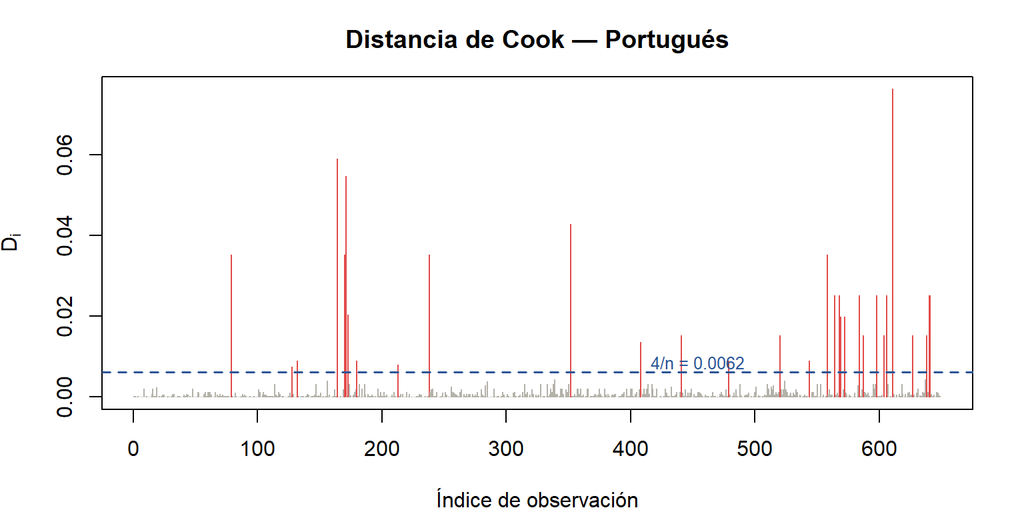

Figure 5.2: Distancia de Cook por observación — Portugués.

```r
cook_por   <- cooks.distance(modelo_por)
hat_por    <- hatvalues(modelo_por)
umbral_por <- 4 / n_por

influyentes_por <- which(cook_por > umbral_por | abs(res_std_por) > 2)

par(mar = c(4, 4, 3, 2))
plot(seq_len(n_por), cook_por,
     type = "h",
     xlab = "Índice de observación", ylab = expression(D[i]),
     main = "Distancia de Cook — Portugués",
     col  = ifelse(cook_por > umbral_por, col_rojo, "#B4B2A9"))
abline(h = umbral_por, lty = 2, col = col_azul, lwd = 1.5)
text(x = n_por * 0.7, y = umbral_por * 1.4,
     labels = sprintf("4/n = %.4f", umbral_por),
     col = col_azul, cex = 0.8)
```

```r
if (length(influyentes_por) > 0) {
  tab_inf_por <- data.frame(
    Obs      = influyentes_por,
    failures = por$failures[influyentes_por],
    G3       = por$G3[influyentes_por],
    Res.Std  = round(res_std_por[influyentes_por], 3),
    Leverage = round(hat_por[influyentes_por], 4),
    Cook.D   = round(cook_por[influyentes_por], 4)
  )
  kable(tab_inf_por,
        caption = paste0("Observaciones con residuo estandarizado > 2 o",
                         " distancia de Cook > 4/n — Portugués."),
        row.names = FALSE)
} else {
  cat("No se identificaron observaciones influyentes bajo los umbrales definidos.\n")
}
```

Table 5.2: Observaciones con residuo estandarizado > 2 o distancia de Cook > 4/n — Portugués.

| Obs | failures | G3 | Res.Std | Leverage | Cook.D |
| --- | --- | --- | --- | --- | --- |
| 79 | 3 | 10 | 1.385 | 0.0354 | 0.0352 |
| 128 | 2 | 11 | 0.984 | 0.0154 | 0.0076 |
| 132 | 3 | 8 | 0.700 | 0.0354 | 0.0090 |
| 156 | 0 | 6 | -2.149 | 0.0018 | 0.0041 |
| 164 | 2 | 0 | -2.745 | 0.0154 | 0.0590 |
| 170 | 3 | 10 | 1.385 | 0.0354 | 0.0352 |
| 171 | 3 | 11 | 1.728 | 0.0354 | 0.0548 |
| 173 | 1 | 1 | -3.115 | 0.0042 | 0.0204 |
| 180 | 3 | 8 | 0.700 | 0.0354 | 0.0090 |
| 213 | 1 | 16 | 1.942 | 0.0042 | 0.0079 |
| 238 | 3 | 10 | 1.385 | 0.0354 | 0.0352 |
| 339 | 0 | 19 | 2.229 | 0.0018 | 0.0044 |
| 352 | 2 | 15 | 2.340 | 0.0154 | 0.0428 |
| 408 | 2 | 12 | 1.323 | 0.0154 | 0.0137 |
| 441 | 0 | 0 | -4.169 | 0.0018 | 0.0153 |
| 479 | 3 | 8 | 0.700 | 0.0354 | 0.0090 |
| 520 | 0 | 0 | -4.169 | 0.0018 | 0.0153 |
| 524 | 0 | 6 | -2.149 | 0.0018 | 0.0041 |
| 544 | 3 | 8 | 0.700 | 0.0354 | 0.0090 |
| 558 | 3 | 10 | 1.385 | 0.0354 | 0.0352 |
| 564 | 1 | 0 | -3.452 | 0.0042 | 0.0251 |
| 568 | 1 | 0 | -3.452 | 0.0042 | 0.0251 |
| 569 | 3 | 9 | 1.043 | 0.0354 | 0.0199 |
| 572 | 3 | 9 | 1.043 | 0.0354 | 0.0199 |
| 584 | 1 | 0 | -3.452 | 0.0042 | 0.0251 |
| 587 | 0 | 0 | -4.169 | 0.0018 | 0.0153 |
| 598 | 1 | 0 | -3.452 | 0.0042 | 0.0251 |
| 604 | 0 | 0 | -4.169 | 0.0018 | 0.0153 |
| 606 | 1 | 0 | -3.452 | 0.0042 | 0.0251 |
| 611 | 3 | 0 | -2.040 | 0.0354 | 0.0763 |
| 627 | 0 | 0 | -4.169 | 0.0018 | 0.0153 |
| 637 | 0 | 19 | 2.229 | 0.0018 | 0.0044 |
| 638 | 0 | 0 | -4.169 | 0.0018 | 0.0153 |
| 640 | 1 | 0 | -3.452 | 0.0042 | 0.0251 |
| 641 | 1 | 0 | -3.452 | 0.0042 | 0.0251 |

# 6 Intervalos de Confianza y Predicciones

## 6.1 Intervalos de confianza para los parámetros

```r
t_crit_mat <- qt(1 - ALPHA/2, df = n_mat - 2)
t_crit_por <- qt(1 - ALPHA/2, df = n_por - 2)

CI_b0_mat <- b0_mat + c(-1, 1) * t_crit_mat * SE_b0_mat
CI_b1_mat <- b1_mat + c(-1, 1) * t_crit_mat * SE_b1_mat
CI_b0_por <- b0_por + c(-1, 1) * t_crit_por * SE_b0_por
CI_b1_por <- b1_por + c(-1, 1) * t_crit_por * SE_b1_por

ic_tab <- data.frame(
  Materia    = c("MAT", "MAT", "POR", "POR"),
  Parámetro  = c("β₀", "β₁", "β₀", "β₁"),
  Estimación = round(c(b0_mat, b1_mat, b0_por, b1_por), 4),
  LI_95      = round(c(CI_b0_mat[1], CI_b1_mat[1],
                        CI_b0_por[1], CI_b1_por[1]), 4),
  LS_95      = round(c(CI_b0_mat[2], CI_b1_mat[2],
                        CI_b0_por[2], CI_b1_por[2]), 4)
)
names(ic_tab)[4:5] <- c("LI 95%", "LS 95%")

kable(ic_tab,
      caption = "Intervalos de confianza al 95% para los parámetros del modelo.",
      row.names = FALSE)
```

Table 6.1: Intervalos de confianza al 95% para los parámetros del modelo.

| Materia | Parámetro | Estimación | LI 95% | LS 95% |
| --- | --- | --- | --- | --- |
| MAT | β₀ | 11.1572 | 10.6931 | 11.6214 |
| MAT | β₁ | -2.2204 | -2.7903 | -1.6505 |
| POR | β₀ | 12.3813 | 12.1366 | 12.6259 |
| POR | β₁ | -2.1419 | -2.5285 | -1.7554 |

## 6.2 Predicciones con bandas de confianza

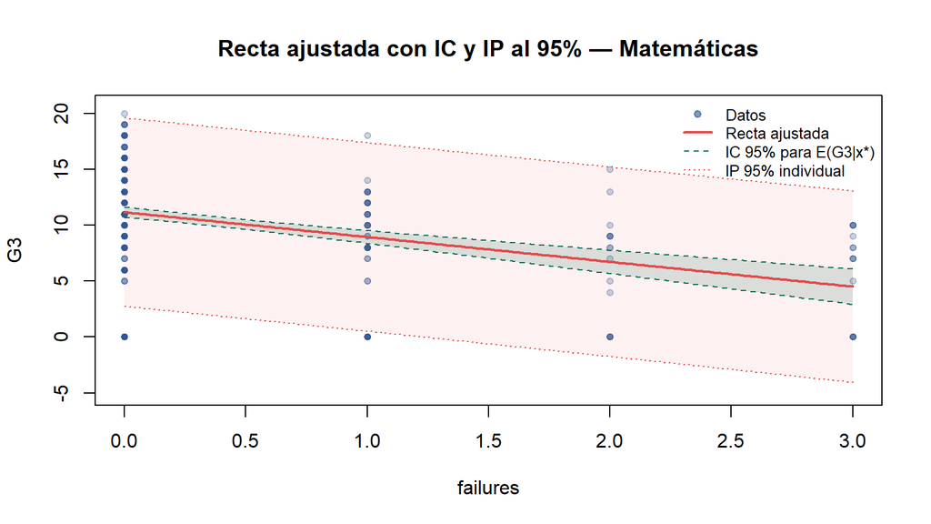

Figure 6.1: Recta ajustada con intervalos de confianza (verde) y predicción (rojo) al 95% — Matemáticas.

```r
x_seq_mat <- seq(min(x_mat), max(x_mat), length.out = 200)

pred_ic_mat <- predict(modelo_mat,
                       newdata  = data.frame(failures = x_seq_mat),
                       interval = "confidence", level = 1 - ALPHA)
pred_ip_mat <- predict(modelo_mat,
                       newdata  = data.frame(failures = x_seq_mat),
                       interval = "prediction", level = 1 - ALPHA)

plot(x_mat, y_mat,
     xlab = "failures", ylab = "G3",
     main = "Recta ajustada con IC y IP al 95% — Matemáticas",
     pch = 19, col = adjustcolor(col_azul, 0.25), cex = 0.75,
     ylim = c(min(pred_ip_mat[,"lwr"]) - 1, max(pred_ip_mat[,"upr"]) + 1))

polygon(c(x_seq_mat, rev(x_seq_mat)),
        c(pred_ip_mat[,"upr"], rev(pred_ip_mat[,"lwr"])),
        col = adjustcolor(col_rojo, 0.08), border = NA)
polygon(c(x_seq_mat, rev(x_seq_mat)),
        c(pred_ic_mat[,"upr"], rev(pred_ic_mat[,"lwr"])),
        col = adjustcolor("#0F6E56", 0.15), border = NA)

lines(x_seq_mat, pred_ic_mat[,"fit"], col = col_rojo,  lwd = 2)
lines(x_seq_mat, pred_ic_mat[,"lwr"], col = "#0F6E56", lty = 2, lwd = 1.2)
lines(x_seq_mat, pred_ic_mat[,"upr"], col = "#0F6E56", lty = 2, lwd = 1.2)
lines(x_seq_mat, pred_ip_mat[,"lwr"], col = col_rojo,  lty = 3, lwd = 1.2)
lines(x_seq_mat, pred_ip_mat[,"upr"], col = col_rojo,  lty = 3, lwd = 1.2)

legend("topright",
       legend = c("Datos", "Recta ajustada",
                  "IC 95% para E(G3|x*)", "IP 95% individual"),
       col = c(adjustcolor(col_azul, 0.6), col_rojo, "#0F6E56", col_rojo),
       lty = c(NA, 1, 2, 3), pch = c(19, NA, NA, NA),
       lwd = c(NA, 2, 1.2, 1.2), bty = "n", cex = 0.8)
```

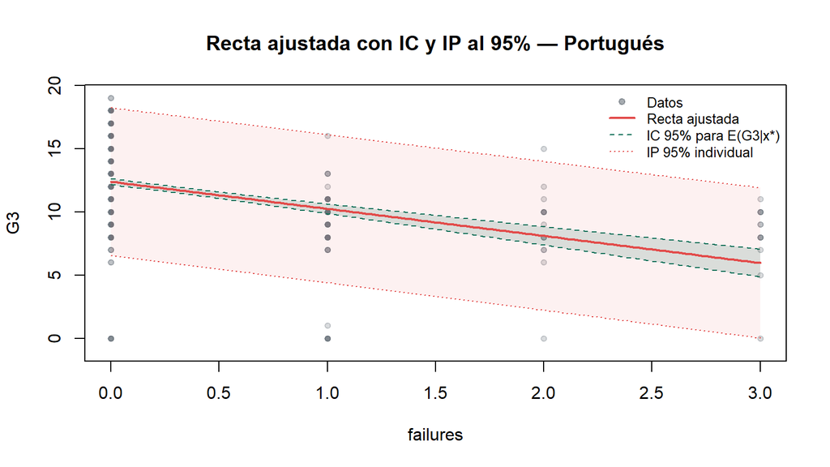

Figure 6.2: Recta ajustada con intervalos de confianza (verde) y predicción (rojo) al 95% — Portugués.

```r
x_seq_por <- seq(min(x_por), max(x_por), length.out = 200)

pred_ic_por <- predict(modelo_por,
                       newdata  = data.frame(failures = x_seq_por),
                       interval = "confidence", level = 1 - ALPHA)
pred_ip_por <- predict(modelo_por,
                       newdata  = data.frame(failures = x_seq_por),
                       interval = "prediction", level = 1 - ALPHA)

plot(x_por, y_por,
     xlab = "failures", ylab = "G3",
     main = "Recta ajustada con IC y IP al 95% — Portugués",
     pch = 19, col = adjustcolor(col_gris, 0.25), cex = 0.75,
     ylim = c(min(pred_ip_por[,"lwr"]) - 1, max(pred_ip_por[,"upr"]) + 1))

polygon(c(x_seq_por, rev(x_seq_por)),
        c(pred_ip_por[,"upr"], rev(pred_ip_por[,"lwr"])),
        col = adjustcolor(col_rojo, 0.08), border = NA)
polygon(c(x_seq_por, rev(x_seq_por)),
        c(pred_ic_por[,"upr"], rev(pred_ic_por[,"lwr"])),
        col = adjustcolor("#0F6E56", 0.15), border = NA)

lines(x_seq_por, pred_ic_por[,"fit"], col = col_rojo,  lwd = 2)
lines(x_seq_por, pred_ic_por[,"lwr"], col = "#0F6E56", lty = 2, lwd = 1.2)
lines(x_seq_por, pred_ic_por[,"upr"], col = "#0F6E56", lty = 2, lwd = 1.2)
lines(x_seq_por, pred_ip_por[,"lwr"], col = col_rojo,  lty = 3, lwd = 1.2)
lines(x_seq_por, pred_ip_por[,"upr"], col = col_rojo,  lty = 3, lwd = 1.2)

legend("topright",
       legend = c("Datos", "Recta ajustada",
                  "IC 95% para E(G3|x*)", "IP 95% individual"),
       col = c(adjustcolor(col_gris, 0.6), col_rojo, "#0F6E56", col_rojo),
       lty = c(NA, 1, 2, 3), pch = c(19, NA, NA, NA),
       lwd = c(NA, 2, 1.2, 1.2), bty = "n", cex = 0.8)
```

## 6.3 Tabla de predicciones puntuales

```r
x_vals <- 0:3

pred_mat_tabla <- predict(modelo_mat,
                           newdata  = data.frame(failures = x_vals),
                           interval = "prediction", level = 1 - ALPHA)
pred_por_tabla <- predict(modelo_por,
                           newdata  = data.frame(failures = x_vals),
                           interval = "prediction", level = 1 - ALPHA)

tab_pred <- data.frame(
  failures    = x_vals,
  G3_hat_MAT  = round(pred_mat_tabla[,"fit"], 3),
  IP_LI_MAT   = round(pred_mat_tabla[,"lwr"], 3),
  IP_LS_MAT   = round(pred_mat_tabla[,"upr"], 3),
  G3_hat_POR  = round(pred_por_tabla[,"fit"], 3),
  IP_LI_POR   = round(pred_por_tabla[,"lwr"], 3),
  IP_LS_POR   = round(pred_por_tabla[,"upr"], 3)
)
names(tab_pred) <- c("failures",
                      "Ĝ3 MAT", "LI 95% MAT", "LS 95% MAT",
                      "Ĝ3 POR", "LI 95% POR", "LS 95% POR")

kable(tab_pred,
      caption = paste0("Predicciones puntuales e intervalos de predicción",
                       " al 95% para valores de failures = 0, 1, 2, 3."),
      row.names = FALSE)
```

Table 6.2: Predicciones puntuales e intervalos de predicción al 95% para valores de failures = 0, 1, 2, 3.

| failures | Ĝ3 MAT | LI 95% MAT | LS 95% MAT | Ĝ3 POR | LI 95% POR | LS 95% POR |
| --- | --- | --- | --- | --- | --- | --- |
| 0 | 11.157 | 2.732 | 19.583 | 12.381 | 6.539 | 18.223 |
| 1 | 8.937 | 0.505 | 17.368 | 10.239 | 4.390 | 16.089 |
| 2 | 6.716 | -1.760 | 15.193 | 8.097 | 2.216 | 13.979 |
| 3 | 4.496 | -4.063 | 13.055 | 5.955 | 0.016 | 11.895 |

# 7 Discusión y Conclusiones

Los modelos de regresión lineal simple obtenidos confirman que la historia de reprobación (`failures`) es la variable con mayor capacidad predictiva de la nota final (G3) de entre las externas al proceso evaluativo, con correlaciones de $r = −0.36$ en Matemáticas y de $r = −0.39$ en Portugués.

El contraste de supuestos nos permite comprobar que los residuos no se distribuyen de manera normal perfecta (Shapiro-Wilk rechaza la hipótesis nula en ambos casos), explicable en parte por la acumulación de calificaciones de 0 —posibles ausencias al examen final— y la naturaleza discreta de la variable `failures`. No obstante, dado el tamaño de la muestra ($n=395$ en MAT/$n=649$ en POR), el teorema central del límite permitirá garantizar que el procedimiento para realizar inferencias a partir de la distribución t es robusto.

Las predicciones del modelo son lógicas: un estudiante sin reprobaciones tiene una nota esperada de aproximadamente 11.2 puntos en MAT y de 12.4 en POR; cada reprobación adicional hará descender tal pronóstico en aproximadamente 2.2 puntos y 2.1, respectivamente.

# 8 Referencias

Cortez, P., & Silva, A. (2008). Using data mining to predict secondary school student performance. *Proceedings of 5th FUBUTEC 2008*, 5–12.

- Cortez, P. & Silva, A. (2008). *Using Data Mining to Predict Secondary School Student Performance*. En A. Brito y J. Teixeira (Eds.), *Proceedings of 5th FUture BUsiness TEChnology Conference (FUBUTEC 2008)*, pp. 5–12. Porto, Portugal: EUROSIS.
- Montgomery, D. C., Peck, E. A., & Vining, G. G. (2012). *Introduction to Linear Regression Analysis* (5th ed.). Wiley.
- R Core Team (2024). *R: A language and environment for statistical computing*. R Foundation for Statistical Computing. https://www.R-project.org/
- Wickham, H. (2016). *ggplot2: Elegant Graphics for Data Analysis*. Springer-Verlag.

# 9 Anexos

## 9.1 Anexo A: Código del análisis exploratorio

El archivo `explore-data-script.R` contiene el código completo de exploración de datos, cálculo de correlaciones y selección de la variable predictora. Se incluye a continuación el código de las secciones más relevantes.

```r
# Candidatas (sin G1, G2, G3)
candidatas <- c("age", "Medu", "Fedu", "traveltime", "studytime",
                "failures", "famrel", "freetime", "goout",
                "Dalc", "Walc", "health", "absences")

# Correlaciones de Pearson con G3
corr_mat <- sapply(candidatas, function(v) cor(mat[[v]], mat$G3))
corr_por <- sapply(candidatas, function(v) cor(por[[v]], por$G3))

# Ordenar por valor absoluto
corr_mat_ord <- sort(abs(corr_mat), decreasing = TRUE)
corr_por_ord <- sort(abs(corr_por), decreasing = TRUE)

print(round(corr_mat_ord, 4))
print(round(corr_por_ord, 4))
```

## 9.2 Anexo B: Cálculo manual MCO — Matemáticas

```r
x_bar <- mean(mat$failures)
y_bar <- mean(mat$G3)
n     <- nrow(mat)

Sxx <- sum((mat$failures - x_bar)^2)
Sxy <- sum((mat$failures - x_bar) * (mat$G3 - y_bar))
Syy <- sum((mat$G3 - y_bar)^2)

b1_hat <- Sxy / Sxx
b0_hat <- y_bar - b1_hat * x_bar

SCReg <- b1_hat^2 * Sxx
SCE   <- Syy - SCReg
CME   <- SCE / (n - 2)
R2    <- SCReg / Syy
F_stat <- (SCReg / 1) / CME

cat("β̂₀ =", round(b0_hat, 4), "\n")
cat("β̂₁ =", round(b1_hat, 4), "\n")
cat("R²  =", round(R2,     4), "\n")
cat("F   =", round(F_stat, 4), "\n")
```

## 9.3 Anexo C: Matriz de correlaciones completa

```r
library(corrplot)
vars_corr <- cor(mat[, c(candidatas, "G3")], use = "complete.obs")
corrplot(vars_corr, method = "color", type = "upper",
         tl.col = "black", tl.srt = 45,
         col = colorRampPalette(c("#E24B4A", "white", "#2C5697"))(200),
         addCoef.col = "black", number.cex = 0.55,
         title = "Matriz de correlaciones — Matemáticas",
         mar   = c(0, 0, 1.5, 0))
```

## 9.4 Anexo D: Resumen numérico del resumen final exploratorio

```
=============================================================
  RESUMEN FINAL — SELECCIÓN DE VARIABLE PREDICTORA
=============================================================

  MAT — Top 3 candidatas:
    1. failures      |r| = 0.3604  (r = -0.3604)
    2. Medu          |r| = 0.2171  (r = +0.2171)
    3. age           |r| = 0.1616  (r = -0.1616)

  POR — Top 3 candidatas:
    1. failures      |r| = 0.3933  (r = -0.3933)
    2. studytime     |r| = 0.2498  (r = +0.2498)
    3. Medu          |r| = 0.2402  (r = +0.2402)

  >> Predictora seleccionada MAT: failures
  >> Predictora seleccionada POR: failures
=============================================================
```